# MihirHambir_PDS_FinalProject (1)

**FPL Dream Team** **Prediction**

1. **What is FPL?**

Fantasy Premier League is an online game in which players collect points based on how real life footballers perform each week. Simply put: you choose a virtual team of Premier League footballers, and if their real-life counterparts do well, you get the points.

1.2 **Rules**

- You are constrained to a budget of 100m to choose players. (better players cost more money)
- You must pick 15 players; 2 Goalkeepers, 5 Defenders, 5 Midfielders and 3 Forwards.
- Only 11 players must be on the pitch. You can play any formation you want.
- You can choose only 3 players from any given team.
- Only the 11 players selected to play can earn points each week.

1.3 **Objective**

- The primary objective of this project is to enable fantasy football players with data driven insights derived from the comprehensive analysis of the player's performance data. By extracting meaningful patterns and trends from the data, the project aims to optimize team selection strategies , improve team performance, and enhance the overall fantasy football experience for the participants.

```python
from bs4 import BeautifulSoup
import requests
import pandas as pd

url = 'https://fantasy.premierleague.com/api/bootstrap-static/'
```

```python
response = requests.get(url)
Elements_df = pd.DataFrame(response.json()['elements'])
Elements_df.head(10)
```

|  | chance_of_playing_next_round | chance_of_playing_this_round | code | cost_change_event | cost_change_event_fall | cost_change_start | cost_change_start_fall | dreamteam_count | element_type | ep_next | ... | now_cost_rank | now_cost_rank_type | form_rank | form_rank_type | points_per_game_rank | points_per_game_rank_type | selected_rank | selected_rank_type | starts_per_90 | clean_sheets_per_90 |
| --- | --- | --- | --- | --- | --- | --- | --- | --- | --- | --- | --- | --- | --- | --- | --- | --- | --- | --- | --- | --- | --- |
| 0 | 0.0 | 0.0 | 232223 | 0 | 0 | -1 | 1 | 0 | 4 | 0.0 | ... | 559 | 104 | 599 | 56 | 713 | 77 | 352 | 51 | 0.00 | 0.00 |
| 1 | NaN | NaN | 58822 | 0 | 0 | -2 | 2 | 0 | 2 | 1.0 | ... | 849 | 271 | 395 | 133 | 452 | 154 | 244 | 98 | 0.00 | 0.00 |
| 2 | 100.0 | 100.0 | 153256 | 0 | 0 | -1 | 1 | 0 | 3 | 1.0 | ... | 530 | 316 | 586 | 199 | 306 | 127 | 475 | 155 | 0.00 | 0.00 |
| 3 | 100.0 | 100.0 | 438098 | 0 | 0 | -1 | 1 | 0 | 3 | 1.2 | ... | 122 | 74 | 383 | 178 | 284 | 116 | 449 | 143 | 0.62 | 0.31 |
| 4 | 100.0 | 100.0 | 226597 | 0 | 0 | 4 | -4 | 3 | 2 | 5.0 | ... | 117 | 13 | 65 | 22 | 44 | 6 | 9 | 2 | 1.00 | 0.47 |
| 5 | 100.0 | 100.0 | 219847 | 0 | 0 | 0 | 0 | 5 | 3 | 8.2 | ... | 23 | 15 | 10 | 4 | 23 | 16 | 49 | 16 | 1.03 | 0.55 |
| 6 | 100.0 | 100.0 | 205651 | 0 | 0 | -3 | 3 | 1 | 4 | 3.4 | ... | 18 | 7 | 150 | 22 | 126 | 23 | 119 | 21 | 1.06 | 0.68 |
| 7 | 100.0 | 100.0 | 85955 | 0 | 0 | -2 | 2 | 0 | 3 | 1.4 | ... | 127 | 77 | 342 | 163 | 344 | 150 | 346 | 105 | 0.99 | 0.39 |
| 8 | NaN | NaN | 440854 | -1 | 1 | -4 | 4 | 1 | 2 | 2.4 | ... | 682 | 164 | 214 | 64 | 84 | 15 | 211 | 85 | 1.05 | 0.57 |
| 9 | 0.0 | 0.0 | 479683 | 0 | 0 | 0 | 0 | 0 | 3 | 0.0 | ... | 429 | 251 | 674 | 248 | 759 | 301 | 557 | 195 | 0.00 | 0.00 |

10 rows × 88 columns

```python
teams_df = pd.DataFrame(response.json()['teams'])
teams_df
```

|  | code | draw | form | id | loss | name | played | points | position | short_name | ... | team_division | unavailable | win | strength_overall_home | strength_overall_away | strength_attack_home | strength_attack_away | strength_defence_home | strength_defence_away | pulse_id |
| --- | --- | --- | --- | --- | --- | --- | --- | --- | --- | --- | --- | --- | --- | --- | --- | --- | --- | --- | --- | --- | --- |
| 0 | 3 | 0 | None | 1 | 0 | Arsenal | 0 | 0 | 0 | ARS | ... | None | False | 0 | 1350 | 1365 | 1370 | 1370 | 1330 | 1360 | 1 |
| 1 | 7 | 0 | None | 2 | 0 | Aston Villa | 0 | 0 | 0 | AVL | ... | None | False | 0 | 1160 | 1285 | 1140 | 1220 | 1180 | 1350 | 2 |
| 2 | 91 | 0 | None | 3 | 0 | Bournemouth | 0 | 0 | 0 | BOU | ... | None | False | 0 | 1100 | 1100 | 1055 | 1130 | 1145 | 1075 | 127 |
| 3 | 94 | 0 | None | 4 | 0 | Brentford | 0 | 0 | 0 | BRE | ... | None | False | 0 | 1100 | 1100 | 1110 | 1055 | 1090 | 1150 | 130 |
| 4 | 36 | 0 | None | 5 | 0 | Brighton | 0 | 0 | 0 | BHA | ... | None | False | 0 | 1100 | 1210 | 1070 | 1180 | 1135 | 1240 | 131 |
| 5 | 90 | 0 | None | 6 | 0 | Burnley | 0 | 0 | 0 | BUR | ... | None | False | 0 | 1045 | 1050 | 1050 | 1050 | 1040 | 1050 | 43 |
| 6 | 8 | 0 | None | 7 | 0 | Chelsea | 0 | 0 | 0 | CHE | ... | None | False | 0 | 1125 | 1190 | 1080 | 1150 | 1170 | 1230 | 4 |
| 7 | 31 | 0 | None | 8 | 0 | Crystal Palace | 0 | 0 | 0 | CRY | ... | None | False | 0 | 1070 | 1100 | 1080 | 1120 | 1060 | 1085 | 6 |
| 8 | 11 | 0 | None | 9 | 0 | Everton | 0 | 0 | 0 | EVE | ... | None | False | 0 | 1095 | 1100 | 1125 | 1125 | 1065 | 1080 | 7 |
| 9 | 54 | 0 | None | 10 | 0 | Fulham | 0 | 0 | 0 | FUL | ... | None | False | 0 | 1055 | 1175 | 1050 | 1180 | 1060 | 1170 | 34 |
| 10 | 14 | 0 | None | 11 | 0 | Liverpool | 0 | 0 | 0 | LIV | ... | None | False | 0 | 1240 | 1370 | 1210 | 1350 | 1270 | 1390 | 10 |
| 11 | 102 | 0 | None | 12 | 0 | Luton | 0 | 0 | 0 | LUT | ... | None | False | 0 | 1055 | 1090 | 1020 | 1060 | 1090 | 1120 | 163 |
| 12 | 43 | 0 | None | 13 | 0 | Man City | 0 | 0 | 0 | MCI | ... | None | False | 0 | 1355 | 1365 | 1350 | 1360 | 1360 | 1370 | 11 |
| 13 | 1 | 0 | None | 14 | 0 | Man Utd | 0 | 0 | 0 | MUN | ... | None | False | 0 | 1125 | 1220 | 1130 | 1210 | 1120 | 1230 | 12 |
| 14 | 4 | 0 | None | 15 | 0 | Newcastle | 0 | 0 | 0 | NEW | ... | None | False | 0 | 1105 | 1280 | 1050 | 1210 | 1160 | 1355 | 23 |
| 15 | 17 | 0 | None | 16 | 0 | Nott'm Forest | 0 | 0 | 0 | NFO | ... | None | False | 0 | 1065 | 1100 | 1050 | 1125 | 1080 | 1080 | 15 |
| 16 | 49 | 0 | None | 17 | 0 | Sheffield Utd | 0 | 0 | 0 | SHU | ... | None | False | 0 | 1030 | 1040 | 1045 | 1020 | 1020 | 1060 | 18 |
| 17 | 6 | 0 | None | 18 | 0 | Spurs | 0 | 0 | 0 | TOT | ... | None | False | 0 | 1170 | 1230 | 1110 | 1150 | 1230 | 1310 | 21 |
| 18 | 21 | 0 | None | 19 | 0 | West Ham | 0 | 0 | 0 | WHU | ... | None | False | 0 | 1100 | 1145 | 1055 | 1140 | 1150 | 1150 | 25 |
| 19 | 39 | 0 | None | 20 | 0 | Wolves | 0 | 0 | 0 | WOL | ... | None | False | 0 | 1100 | 1100 | 1085 | 1105 | 1115 | 1100 | 38 |

20 rows × 21 columns

2. **Exploring the Dataset**

```python
Elements_df.shape
```

```
(859, 88)
```

```python
Elements_df.columns
```

```
Index(['chance_of_playing_next_round', 'chance_of_playing_this_round', 'code',
       'cost_change_event', 'cost_change_event_fall', 'cost_change_start',
       'cost_change_start_fall', 'dreamteam_count', 'element_type', 'ep_next',
       'ep_this', 'event_points', 'first_name', 'form', 'id', 'in_dreamteam',
       'news', 'news_added', 'now_cost', 'photo', 'points_per_game',
       'second_name', 'selected_by_percent', 'special', 'squad_number',
       'status', 'team', 'team_code', 'total_points', 'transfers_in',
       'transfers_in_event', 'transfers_out', 'transfers_out_event',
       'value_form', 'value_season', 'web_name', 'minutes', 'goals_scored',
       'assists', 'clean_sheets', 'goals_conceded', 'own_goals',
       'penalties_saved', 'penalties_missed', 'yellow_cards', 'red_cards',
       'saves', 'bonus', 'bps', 'influence', 'creativity', 'threat',
       'ict_index', 'starts', 'expected_goals', 'expected_assists',
       'expected_goal_involvements', 'expected_goals_conceded',
       'influence_rank', 'influence_rank_type', 'creativity_rank',
       'creativity_rank_type', 'threat_rank', 'threat_rank_type',
       'ict_index_rank', 'ict_index_rank_type',
       'corners_and_indirect_freekicks_order',
       'corners_and_indirect_freekicks_text', 'direct_freekicks_order',
       'direct_freekicks_text', 'penalties_order', 'penalties_text',
       'expected_goals_per_90', 'saves_per_90', 'expected_assists_per_90',
       'expected_goal_involvements_per_90', 'expected_goals_conceded_per_90',
       'goals_conceded_per_90', 'now_cost_rank', 'now_cost_rank_type',
       'form_rank', 'form_rank_type', 'points_per_game_rank',
       'points_per_game_rank_type', 'selected_rank', 'selected_rank_type',
       'starts_per_90', 'clean_sheets_per_90'],
      dtype='object')
```

```python
Elements_df.info()
```

```
<class 'pandas.core.frame.DataFrame'>
RangeIndex: 859 entries, 0 to 858
Data columns (total 88 columns):
 #   Column                                Non-Null Count  Dtype
---  ------                                --------------  -----
 0   chance_of_playing_next_round          657 non-null    float64
 1   chance_of_playing_this_round          655 non-null    float64
 2   code                                  859 non-null    int64
 3   cost_change_event                     859 non-null    int64
 4   cost_change_event_fall                859 non-null    int64
 5   cost_change_start                     859 non-null    int64
 6   cost_change_start_fall                859 non-null    int64
 7   dreamteam_count                       859 non-null    int64
 8   element_type                          859 non-null    int64
 9   ep_next                               859 non-null    object
```

[output cut: 80 more lines]

```python
teams_df.columns
```

```
Index(['code', 'draw', 'form', 'id', 'loss', 'name', 'played', 'points',
       'position', 'short_name', 'strength', 'team_division', 'unavailable',
       'win', 'strength_overall_home', 'strength_overall_away',
       'strength_attack_home', 'strength_attack_away', 'strength_defence_home',
       'strength_defence_away', 'pulse_id'],
      dtype='object')
```

3**. Feature Engineering**

3.1 **Dealing with null values**

```python
Elements_df.isnull().sum()
```

```
chance_of_playing_next_round    202
chance_of_playing_this_round    204
code                              0
cost_change_event                 0
cost_change_event_fall            0
                               ...
points_per_game_rank_type         0
selected_rank                     0
selected_rank_type                0
starts_per_90                     0
clean_sheets_per_90               0
Length: 88, dtype: int64
```

3.2 **Dealing with Players who did not play a single minute**

```python
idx = Elements_df[(Elements_df['minutes'] == 0) & (Elements_df['in_dreamteam'] == False)].index
df = Elements_df.drop(idx, axis=0)
```

3.3 **Feature Selection**

```python
# Merge team name from teams_df into Elements_df
Elements_df = Elements_df.merge(teams_df[['code', 'name', 'strength_overall_home', 'strength_overall_away']], how='left', left_on='team_code', right_on='code')

# Create full name
Elements_df['full_name'] = Elements_df['first_name'] + " " + Elements_df['second_name']

# Map element type name
Elements_df['position'] = Elements_df.element_type.map({x['id']: x['singular_name_short'] for x in response.json()['element_types']})

# Select columns for players_df
players_df = Elements_df[['team_code','name','full_name','web_name','element_type','position','form','in_dreamteam','ict_index','ep_next','now_cost','points_per_game','total_points','minutes','goals_scored','assists','clean_sheets','goals_conceded','own_goals','penalties_saved','penalties_missed','yellow_cards','red_cards','saves','bonus','bps','influence','creativity','threat','strength_overall_home','strength_overall_away']]

players_df
```

|  | team_code | name | full_name | web_name | element_type | position | form | in_dreamteam | ict_index | ep_next | ... | yellow_cards | red_cards | saves | bonus | bps | influence | creativity | threat | strength_overall_home | strength_overall_away |
| --- | --- | --- | --- | --- | --- | --- | --- | --- | --- | --- | --- | --- | --- | --- | --- | --- | --- | --- | --- | --- | --- |
| 0 | 3 | Arsenal | Folarin Balogun | Balogun | 4 | FWD | 0.0 | False | 0.0 | 0.0 | ... | 0 | 0 | 0 | 0 | 0 | 0.0 | 0.0 | 0.0 | 1350 | 1365 |
| 1 | 3 | Arsenal | Cédric Alves Soares | Cédric | 2 | DEF | 0.0 | False | 0.6 | 1.0 | ... | 0 | 0 | 0 | 0 | 15 | 2.0 | 4.3 | 0.0 | 1350 | 1365 |
| 2 | 3 | Arsenal | Mohamed Elneny | M.Elneny | 3 | MID | 0.0 | False | 1.6 | 1.0 | ... | 0 | 0 | 0 | 0 | 16 | 4.0 | 2.1 | 10.0 | 1350 | 1365 |
| 3 | 3 | Arsenal | Fábio Ferreira Vieira | Fábio Vieira | 3 | MID | 0.2 | False | 25.5 | 1.2 | ... | 0 | 1 | 0 | 0 | 67 | 82.8 | 88.8 | 85.0 | 1350 | 1365 |
| 4 | 3 | Arsenal | Gabriel dos Santos Magalhães | Gabriel | 2 | DEF | 4.0 | True | 113.8 | 5.0 | ... | 4 | 0 | 0 | 7 | 639 | 649.4 | 118.2 | 368.0 | 1350 | 1365 |
| ... | ... | ... | ... | ... | ... | ... | ... | ... | ... | ... | ... | ... | ... | ... | ... | ... | ... | ... | ... | ... | ... |
| 854 | 39 | Wolves | Noha Lemina | N.Lemina | 3 | MID | 0.0 | False | 0.0 | 0.0 | ... | 0 | 0 | 0 | 0 | 0 | 0.0 | 0.0 | 0.0 | 1100 | 1100 |
| 855 | 39 | Wolves | Wesley Okoduwa | Okoduwa | 2 | DEF | 0.0 | False | 0.0 | 0.0 | ... | 0 | 0 | 0 | 0 | 0 | 0.0 | 0.0 | 0.0 | 1100 | 1100 |
| 856 | 39 | Wolves | Leon Chiwome | Chiwome | 4 | FWD | 0.0 | False | 2.2 | 0.0 | ... | 0 | 0 | 0 | 0 | 12 | 7.8 | 1.2 | 13.0 | 1100 | 1100 |
| 857 | 39 | Wolves | Fletcher Holman | Holman | 4 | FWD | 0.0 | False | 0.0 | 0.0 | ... | 0 | 0 | 0 | 0 | 0 | 0.0 | 0.0 | 0.0 | 1100 | 1100 |
| 858 | 39 | Wolves | Temple Ojinnaka | Ojinnaka | 3 | MID | 0.0 | False | 0.0 | 0.0 | ... | 0 | 0 | 0 | 0 | 0 | 0.0 | 0.0 | 0.0 | 1100 | 1100 |

859 rows × 31 columns

```python
teams_df['name'].unique()
```

```
array(['Arsenal', 'Aston Villa', 'Bournemouth', 'Brentford', 'Brighton',
       'Burnley', 'Chelsea', 'Crystal Palace', 'Everton', 'Fulham',
       'Liverpool', 'Luton', 'Man City', 'Man Utd', 'Newcastle',
       "Nott'm Forest", 'Sheffield Utd', 'Spurs', 'West Ham', 'Wolves'],
      dtype=object)
```

```python
players_df.rename(columns={'name': 'team_name'}, inplace=True)
```

```python
players_df.head(10)
```

|  | team_code | team_name | full_name | web_name | element_type | position | form | in_dreamteam | ict_index | ep_next | ... | yellow_cards | red_cards | saves | bonus | bps | influence | creativity | threat | strength_overall_home | strength_overall_away |
| --- | --- | --- | --- | --- | --- | --- | --- | --- | --- | --- | --- | --- | --- | --- | --- | --- | --- | --- | --- | --- | --- |
| 0 | 3 | Arsenal | Folarin Balogun | Balogun | 4 | FWD | 0.0 | False | 0.0 | 0.0 | ... | 0 | 0 | 0 | 0 | 0 | 0.0 | 0.0 | 0.0 | 1350 | 1365 |
| 1 | 3 | Arsenal | Cédric Alves Soares | Cédric | 2 | DEF | 0.0 | False | 0.6 | 1.0 | ... | 0 | 0 | 0 | 0 | 15 | 2.0 | 4.3 | 0.0 | 1350 | 1365 |
| 2 | 3 | Arsenal | Mohamed Elneny | M.Elneny | 3 | MID | 0.0 | False | 1.6 | 1.0 | ... | 0 | 0 | 0 | 0 | 16 | 4.0 | 2.1 | 10.0 | 1350 | 1365 |
| 3 | 3 | Arsenal | Fábio Ferreira Vieira | Fábio Vieira | 3 | MID | 0.2 | False | 25.5 | 1.2 | ... | 0 | 1 | 0 | 0 | 67 | 82.8 | 88.8 | 85.0 | 1350 | 1365 |
| 4 | 3 | Arsenal | Gabriel dos Santos Magalhães | Gabriel | 2 | DEF | 4.0 | True | 113.8 | 5.0 | ... | 4 | 0 | 0 | 7 | 639 | 649.4 | 118.2 | 368.0 | 1350 | 1365 |
| 5 | 3 | Arsenal | Kai Havertz | Havertz | 3 | MID | 7.2 | False | 222.0 | 8.2 | ... | 10 | 0 | 0 | 15 | 479 | 708.2 | 575.1 | 938.0 | 1350 | 1365 |
| 6 | 3 | Arsenal | Gabriel Fernando de Jesus | G.Jesus | 4 | FWD | 2.4 | False | 149.8 | 3.4 | ... | 6 | 0 | 0 | 10 | 261 | 358.0 | 390.4 | 747.0 | 1350 | 1365 |
| 7 | 3 | Arsenal | Jorge Luiz Frello Filho | Jorginho | 3 | MID | 0.4 | False | 36.8 | 1.4 | ... | 1 | 0 | 0 | 1 | 179 | 165.0 | 187.8 | 16.0 | 1350 | 1365 |
| 8 | 3 | Arsenal | Jakub Kiwior | Kiwior | 2 | DEF | 1.4 | False | 42.7 | 2.4 | ... | 1 | 0 | 0 | 1 | 257 | 228.8 | 106.9 | 90.0 | 1350 | 1365 |
| 9 | 3 | Arsenal | Marcus Oliveira Alencar | Marquinhos | 3 | MID | 0.0 | False | 0.0 | 0.0 | ... | 0 | 0 | 0 | 0 | 0 | 0.0 | 0.0 | 0.0 | 1350 | 1365 |

10 rows × 31 columns

3.4 **Adding Fixture Difficulty Rating (FDR) Feature.**

```
The FDR is based on a complex algorithm developed by FPL experts.

A set of formulas process key Opta data variables, along with each team's home and away form for the past six matches, to generate a rank for the perceived difficulty of each Gameweek opponent.

The FDR is reviewed on a weekly basis and updated as the season progresses.

1: Easiest
2: Easy
3: Moderate
4: Hard
5: Hardest
```

```python
players_df['Fixture_Difficulty_Rate'] = 0
```

```python
Arsenal = {1.:4,  2.:2}
Aston_Villa = {1.:4,  2.:2}
Bournemouth = {1.:2,  2.:3}
Brentford = {1.:2,  2.:3}
Brighton = {1.:4,  2.:3, 3.:3}
Burnley = {1.:4,  2.:2}
Chelsea = {1.:2,  2.:3, 3.:2}
Crystal_Palace = {1.:2,  2.:3}
Everton = {1.:2,  2.:5}
Fulham = {1.:5,  2.:1}
Liverpool = {1.:4,  2.:2}
Luton = {1.:2,  2.:3}
Man_City = {1.:3,  2.:4, 3.:2}
Man_Utd = {1.:5,  2.:3, 3.:3}
Newcastle = {1.:2,  2.:4, 3.:2}
Nottm_Forest = {1.:3,  2.:2}
Sheffield_Utd = {1.:2,  2.:3}
Spurs = {1.:2,  2.:5, 3.:2}
West_Ham = {1.:2,  2.:5}
Wolves = {1.:2,  2.:5}
```

```python
list_of_dicts = [Arsenal, Aston_Villa, Bournemouth, Brentford, Brighton, Burnley, Chelsea, Crystal_Palace, Everton, Fulham, Liverpool,
                 Luton, Man_City, Man_Utd, Newcastle, Nottm_Forest, Sheffield_Utd, Spurs, West_Ham, Wolves]

list_of_teams = ["Arsenal", "Aston Villa", "Bournemouth", "Brentford", "Brighton", "Burnley", "Chelsea", "Crystal Palace", "Everton", "Fulham",
                 "Liverpool", "Luton", "Man City", "Man Utd", "Newcastle", "Nott'm Forest", "Sheffield Utd", "Spurs", "West Ham", "Wolves"]
```

```python
# Filling Fixture Difficulty Ratings (FDR) in players_df
for team in list_of_teams:
    for dic in list_of_dicts:
        if list_of_teams.index(team) != list_of_dicts.index(dic):
            continue
        for week in dic:
            if list_of_teams.index(team) == list_of_dicts.index(dic):
                players_df.loc[players_df['team_name'] == team, 'Fixture_Difficulty_Rate'] = dic[week]
```

```python
players_df
```

|  | team_code | team_name | full_name | web_name | element_type | position | form | in_dreamteam | ict_index | ep_next | ... | red_cards | saves | bonus | bps | influence | creativity | threat | strength_overall_home | strength_overall_away | Fixture_Difficulty_Rate |
| --- | --- | --- | --- | --- | --- | --- | --- | --- | --- | --- | --- | --- | --- | --- | --- | --- | --- | --- | --- | --- | --- |
| 0 | 3 | Arsenal | Folarin Balogun | Balogun | 4 | FWD | 0.0 | False | 0.0 | 0.0 | ... | 0 | 0 | 0 | 0 | 0.0 | 0.0 | 0.0 | 1350 | 1365 | 2 |
| 1 | 3 | Arsenal | Cédric Alves Soares | Cédric | 2 | DEF | 0.0 | False | 0.6 | 1.0 | ... | 0 | 0 | 0 | 15 | 2.0 | 4.3 | 0.0 | 1350 | 1365 | 2 |
| 2 | 3 | Arsenal | Mohamed Elneny | M.Elneny | 3 | MID | 0.0 | False | 1.6 | 1.0 | ... | 0 | 0 | 0 | 16 | 4.0 | 2.1 | 10.0 | 1350 | 1365 | 2 |
| 3 | 3 | Arsenal | Fábio Ferreira Vieira | Fábio Vieira | 3 | MID | 0.2 | False | 25.5 | 1.2 | ... | 1 | 0 | 0 | 67 | 82.8 | 88.8 | 85.0 | 1350 | 1365 | 2 |
| 4 | 3 | Arsenal | Gabriel dos Santos Magalhães | Gabriel | 2 | DEF | 4.0 | True | 113.8 | 5.0 | ... | 0 | 0 | 7 | 639 | 649.4 | 118.2 | 368.0 | 1350 | 1365 | 2 |
| ... | ... | ... | ... | ... | ... | ... | ... | ... | ... | ... | ... | ... | ... | ... | ... | ... | ... | ... | ... | ... | ... |
| 854 | 39 | Wolves | Noha Lemina | N.Lemina | 3 | MID | 0.0 | False | 0.0 | 0.0 | ... | 0 | 0 | 0 | 0 | 0.0 | 0.0 | 0.0 | 1100 | 1100 | 0 |
| 855 | 39 | Wolves | Wesley Okoduwa | Okoduwa | 2 | DEF | 0.0 | False | 0.0 | 0.0 | ... | 0 | 0 | 0 | 0 | 0.0 | 0.0 | 0.0 | 1100 | 1100 | 0 |
| 856 | 39 | Wolves | Leon Chiwome | Chiwome | 4 | FWD | 0.0 | False | 2.2 | 0.0 | ... | 0 | 0 | 0 | 12 | 7.8 | 1.2 | 13.0 | 1100 | 1100 | 0 |
| 857 | 39 | Wolves | Fletcher Holman | Holman | 4 | FWD | 0.0 | False | 0.0 | 0.0 | ... | 0 | 0 | 0 | 0 | 0.0 | 0.0 | 0.0 | 1100 | 1100 | 0 |
| 858 | 39 | Wolves | Temple Ojinnaka | Ojinnaka | 3 | MID | 0.0 | False | 0.0 | 0.0 | ... | 0 | 0 | 0 | 0 | 0.0 | 0.0 | 0.0 | 1100 | 1100 | 0 |

859 rows × 32 columns

4. **Data Analysis and Visualization**

```python
# PLotting the correlation
non_numeric_columns = ['team_name', 'full_name', 'web_name', 'position']
numeric_columns = [col for col in players_df.columns if col not in non_numeric_columns]

correlation = players_df[numeric_columns].corr()['total_points']
print(correlation)
```

```
team_code                 -0.057409
element_type               0.095408
form                       0.772647
in_dreamteam               0.401543
ict_index                  0.953851
ep_next                    0.685832
now_cost                   0.582936
points_per_game            0.897639
total_points               1.000000
minutes                    0.902755
goals_scored               0.780902
assists                    0.773579
clean_sheets               0.867965
goals_conceded             0.770989
own_goals                  0.113925
penalties_saved            0.090075
penalties_missed           0.233805
yellow_cards               0.631621
red_cards                  0.150911
saves                      0.205727
bonus                      0.886511
bps                        0.943332
influence                  0.934999
creativity                 0.793073
threat                     0.819806
strength_overall_home      0.173737
strength_overall_away      0.154373
Fixture_Difficulty_Rate    0.035645
Name: total_points, dtype: float64
```

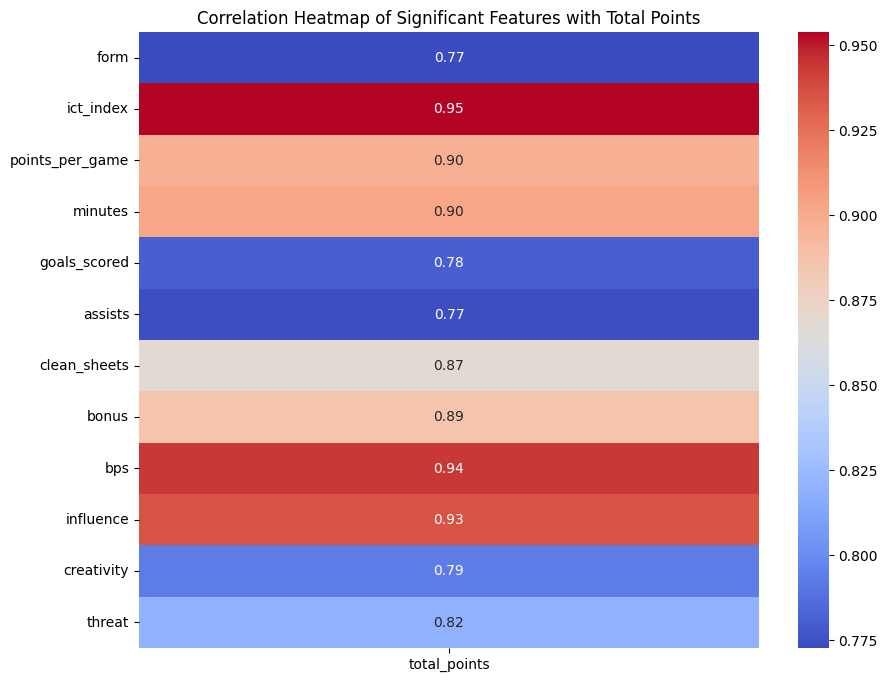

```python
# Selecting significant positive correlation features
significant_features = [
    'form', 'ict_index', 'points_per_game',
    'minutes', 'goals_scored', 'assists', 'clean_sheets', 'bonus',
    'bps', 'influence', 'creativity', 'threat'
]

# Selecting the corresponding columns from players_df
significant_df = players_df[significant_features + ['total_points']]

# Calculating the correlation matrix
corr_matrix = significant_df.corr()

# Selecting only the correlation of significant features with total_points
total_points_corr = corr_matrix['total_points'][significant_features]

# Plotting the heatmap
plt.figure(figsize=(10, 8))
sns.heatmap(total_points_corr.to_frame(), annot=True, cmap='coolwarm', fmt=".2f")
plt.title('Correlation Heatmap of Significant Features with Total Points')
plt.show()
```

Above we can see the most important features which affects the total points of a player. Surprisingly minutes is more correlated with total points than form. Ideally we think if a player is in good form he'll give us more points but iguess that is not the case. The correlation of minustes could be explained by as the player will play more he will tend to give more points.

Now let's see which position has the most players as we have to choose players for all the positions.

And as expected midfielders numbers are the highest. but it is the forwards and midfielders combined which gives the most points.

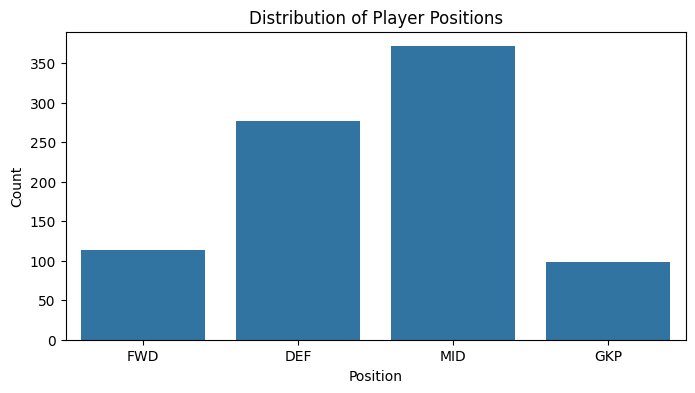

```python
import matplotlib.pyplot as plt
import seaborn as sns

# Distribution of player positions
plt.figure(figsize=(8, 4))
sns.countplot(x='position', data=players_df)
plt.title('Distribution of Player Positions')
plt.xlabel('Position')
plt.ylabel('Count')
plt.show()
```

```python
import numpy as np
players_df.pivot_table(index='position', values='total_points', aggfunc=np.mean)
```

| position | total_points |
| --- | --- |
| DEF | 31.584838 |
| FWD | 37.513274 |
| GKP | 23.918367 |
| MID | 37.800539 |

This also proves the above graph right that forwards and midfielders combined give the most points.

Let's now explore the relationship between position of a player and his value

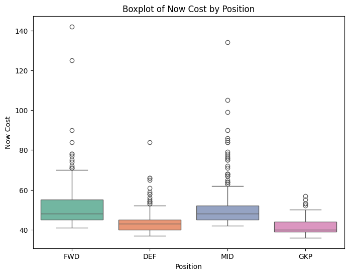

```python
plt.figure(figsize=(8, 6))
sns.boxplot(data=players_df, x='position', y='now_cost', palette='Set2')
plt.title('Boxplot of Now Cost by Position')
plt.xlabel('Position')
plt.ylabel('Now Cost')
plt.show()
```

The Box Plot above clearly addresses that Forward (FWD) Players have the highest Value Distribution, and midfield (MID) players come after them. As well as there are a lot of outlier points but they are not real outliers because the game has variety of players and prices, in other words, a wide range of values.

Let's see a Kernel Density Estimation to understand this better.

[output not shown]

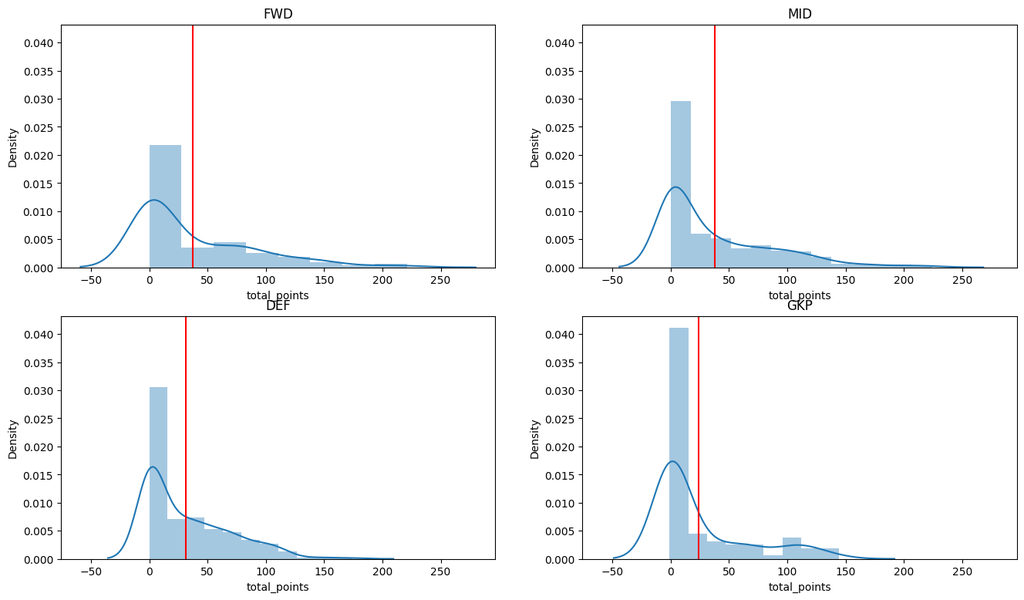

```python
f = plt.figure(figsize=(16,9))
ax1 = f.add_subplot(2,2,1)
ax2 = f.add_subplot(2,2,2,sharex=ax1, sharey=ax1)
ax3 = f.add_subplot(2,2,3,sharex=ax1, sharey=ax1)
ax4 = f.add_subplot(2,2,4,sharex=ax1, sharey=ax1)
ax1.set_title('FWD')
sns.distplot(players_df[players_df.position=='FWD'].total_points, label='FWD',ax=ax1)
ax1.axvline(np.mean(players_df[players_df.position=='FWD'].total_points),color='red', label='mean')
ax2.set_title('MID')
sns.distplot(players_df[players_df.position=='MID'].total_points, label='MID',ax=ax2)
ax2.axvline(np.mean(players_df[players_df.position=='MID'].total_points),color='red', label='mean')
ax3.set_title('DEF')
sns.distplot(players_df[players_df.position=='DEF'].total_points, label='DEF',ax=ax3)
ax3.axvline(np.mean(players_df[players_df.position=='DEF'].total_points),color='red', label='mean')
ax4.set_title('GKP')
sns.distplot(players_df[players_df.position=='GKP'].total_points, label='GKP',ax=ax4)
ax4.axvline(np.mean(players_df[players_df.position=='GKP'].total_points),color='red', label='mean')
plt.show()
```

Given the differences in counts, i thought it would be a good idea to have a look at some kernel density estimations to show the distribution of points based on the position of the players. This should give more of an indication as to the distribution of points for each position. Most of the data is positively skewed and slightly leptokertic, however, the goalkeeper distribution seems to be bimodal. This would make sense as most clubs will have 2-3 goalkeepers at a time and will play the better goalkeeper the majority of the time resulting in more time to earn points and the other 0 to few games as the others would only be switched in times of need when the 1st choice keeper is injured or needs to be rested.